# Protected Areas Practical

# Course overview

- Learn how and why protected areas are important (Lecture)
- Learn the principles of systematic conservation planning (Lecture)
- Learn how to implement a protected area network (Lecture + Practical)

Protected areas are a cornerstone of conservation. In fact, the world has committed to protecting 30% of the planet by 2030. But how do we make that protection meaningful? This practical will use structured decision-making to protect land in Madagascar based on your species distribution maps from your previous practical. The software we will use to do this is `prioritizr`. This is the main paper about using prioritizr for systematic conservation planning: https://conbio.onlinelibrary.wiley.com/doi/full/10.1111/cobi.14376

# Installation

## R and Rstudio

Make sure you have Rstudio and R installed:

- R: https://cran.r-project.org/bin/windows/base/
- Rstudio: https://posit.co/download/rstudio-desktop/

## Download the practical data

1. Go to https://github.com/KiranLDA/MSc_Protected_Areas
2. Click on the big green button ‘CODE’.
3. Select ‘Download ZIP’.
4. Save the file to your computer in your chosen location.
5. Once downloaded, unzip/extract all files in the ZIP file.

## Packages

Go to `code/01_installation.R` to get a list of R packages to install. They are also copied below:

```r
install.packages("prioritizr")
install.packages("prioritizrdata")
install.packages("terra")
install.packages("highs", repos = "https://cran.rstudio.com/")
```

# Exercise 1

While the packages install, we can do this exercise to understand the value of using an optimization. Let’s first try to solve [this problem](https://marxansolutions.org/training/#:~:text=Conservation%20Planning%20Exercise,with%20the%20lowest%20possible%20cost.) by selecting cells for conservation to meet targets for 3 species for the least cost. Once you meet the target, you can compare your solution with the optimal solution.

# Start the practical in R

Now get the code for the practical from Go to `code/02_practical.R`

# Load Packages

```r
library(prioritizr)
library(terra)
```

# Load the files

We are going to be using the species that you are mapping as part of the Species Distribution Modelling (SDM) class. We are going to use the binary presence/absence outputs where the probability of a species presence has been translated into a yes/no.

Each layer describes the spatial distribution of a feature. Here, our feature data correspond to different plant species. Specifically, if the cell (or planning unit) has a 1, as species is predicted to be present in it based on the SDM. If the cell has a 0, then it is predicted to be absent.

## Load species distributions

```r
# put them together into a multi-layer raster
species = terra::rast("data/species.tif")
```

### Plot species individual maps

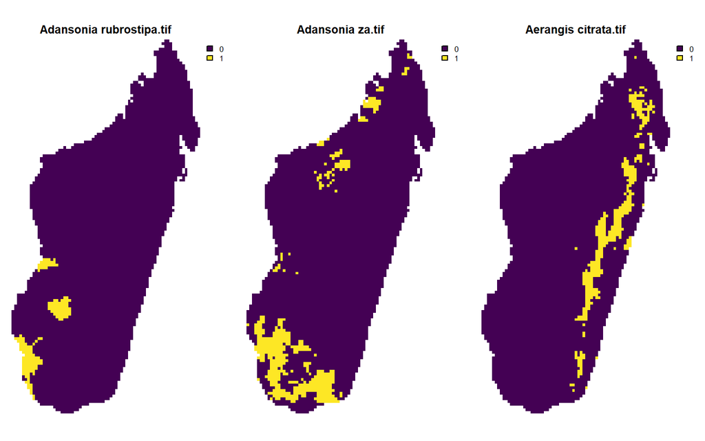

```r
plot(species[[1:3]], nr = 1, axes = FALSE)
```

### Plot species together

We have 41 species that we can use to develop a species richness map.

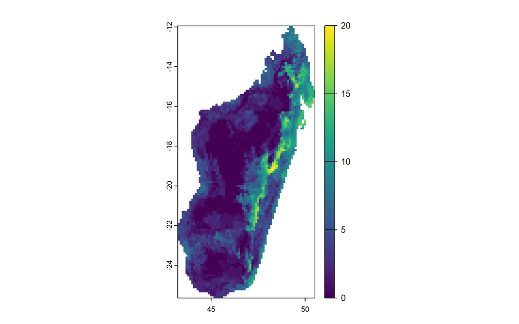

```r
plot(sum(species))
```

## Load Cost Data

A very important element of protected area planning is the cost. Wherever we put a protected area, there will be a cost involved. Cost can be:

- no cost: cost is equal across all planning units, which means the prioritisation will only rely on the biodiversity data. However, a protected area plan that doesn’t account for cost (and therefore people) is not likely to be very helpful.
- directly estimated: we can evaluate the economic losses of converting land to protected land. This can be through the cost of purchasing land, the staff needed to patrol, the revenue from tourism, and the loss of opportunities (loss of mining land, grazing land, agricultural land, and even homes).
- indirectly estimated: we can estimate what land is most costly. For example, the human footprint index is often used to see where people use land. We then make the assumption that areas that people use are most costly and create the greatest conflict, and should be avoided as a place to put a protected area.

Here, it’s an exercise, so we use the Human footprint layer as a proxy for an indirect cost estimate. The layer was downloaded from this paper: https://www.nature.com/articles/s41597-022-01284-8#Sec12

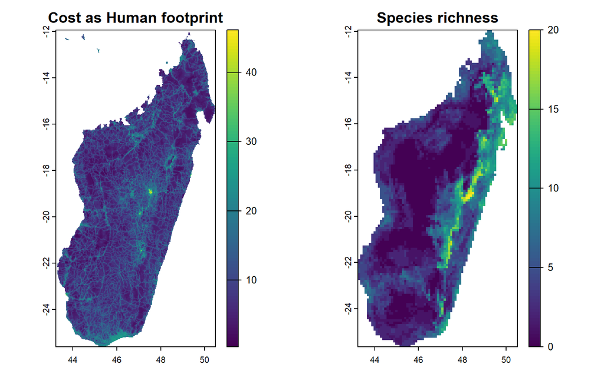

```r
# load the file
cost0 = rast("data/cost.tif")

# Plot the file
par(mfrow = c(1,2)) # put 2 plots side by side
plot(cost0, main = "Cost as Human footprint")
plot(sum(species), main="Species richness")
```

```r
par(mfrow = c(1,1))
```

# Dataset Resolution

Notice that cost is very fine scale while the species data are coarse. We need to lower the resolution of the cost data so that it is the same as the species data.

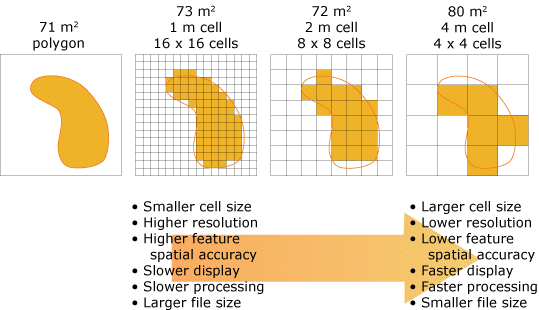

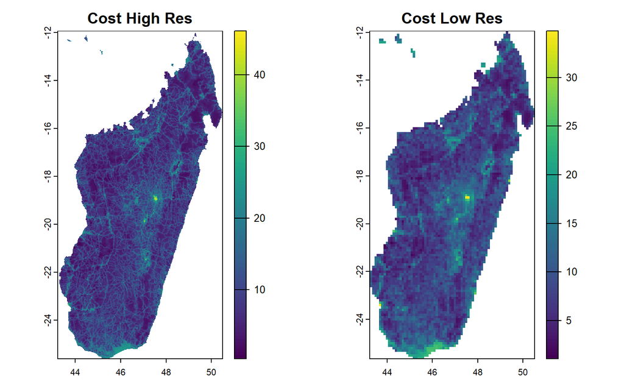

```r
par(mfrow=c(1,2))
plot(cost0, main = "Cost High Res")
cost = terra::aggregate(cost0, fact = 12, fun = "median",  na.rm=TRUE)
plot(cost, main = "Cost Low Res")
```

```r
par(mfrow=c(1,1))
```

# Spatial extent and projection

Why should I care about the spatial extent of my data or it’s projection?

The world is a sphere, and for us to visualise it on paper as a rectangle, we need to make some transformation or “projections”. This can lead to some regions becoming more stretched than others, and some regions being more compressed. The most common projection, the Mercator projection (left), makes the northern hemisphere look larger than the southern hemisphere. We can have equal area projections (right) such as Winkel-Tripel that correct for this, but then make places like New Zealand look very squashed. No projection is perfect.

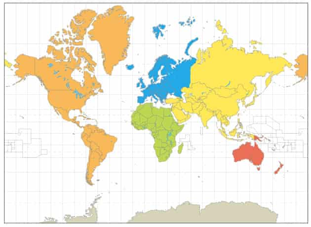

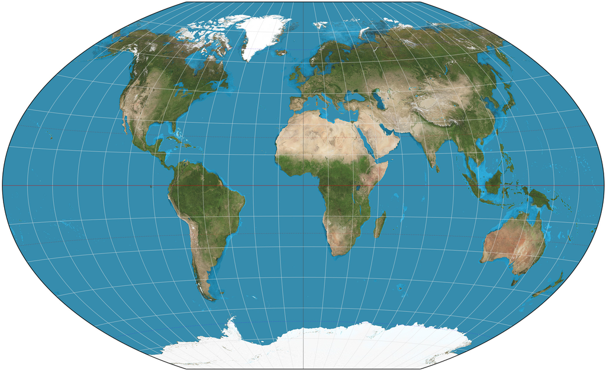

Many datasets each use different projections, so it is important to make sure all the different files have the same extent (x and y limits), and the same resolution (pixel size)

## Extent

```r
ext(cost)
```

```
## SpatExtent : 43.225, 50.525, -25.6416666666667, -11.9416666666667 (xmin, xmax, ymin, ymax)
```

```r
ext(species)
```

```
## SpatExtent : 43.225, 50.525, -25.6416666666667, -11.9416666666667 (xmin, xmax, ymin, ymax)
```

Do they look the same?

## Resolution

Resolution is also important as we need the cells to all line-up to be able to match them and make calulations.

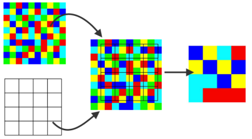

This code is here to check that they line up

```r
res(cost)
```

```
## [1] 0.1 0.1
```

```r
res(species)
```

```
## [1] 0.1 0.1
```

Do they look the same?

# Solvers

`prioritizr` is a package that relies on a solver… to solve the problem.

So let’s make sure that we have a solver installed. This is important because prioritizr interfaces with the solver to use it’s optimization algorithms to generate spatial prioritizations.

Today we are are using the HiGHS solver because it is easy to install. If later you really get into protected area planning, then use your Queen Mary VPN to install the Gurobi software suite and the Gurobi R package for best performance (see the [Gurobi Installation Guide for details](https://prioritizr.net/articles/gurobi_installation_guide.html)).

```r
# test the installation
library(highs)

# if needed, install HiGHS solver, but this should have been done before the practical
# install.packages("highs", repos = "https://cran.rstudio.com/")
```

# Spatial Prioritization

## Formulate the problem

Now, let’s generate a spatial prioritization. We want to solve the following problem:

**I want to protect as many species as possible within my budget by setting cells aside for protection, aiming for 30% of the range of each species**

The things that we need to track are:

- **Budget**: the total cost of the prioritization will represent a 30% of the total land value in the study area. Given this budget, we want the prioritization to increase feature representation, as much as possible,
- **Features**: each feature (i.e. species) would, ideally, have 30% of its distribution covered by the prioritization. In this scenario, we can either purchase all of the land inside a given planning unit, or none of the land inside a given planning unit.
- **Planning Units**: These are sites that we are considering to protect or not. We have the option to protect or not each site. In this case, each site represents one pixel of the raster

We then need to translate this to code:

- We start by creating a new `problem()` that will use a
- **minimum shortfall objective** to spend the budget (via `add_min_shortfall_objective()`), while getting as close as possible to a
- **relative targets of 30%** of the range of each species(via `add_relative_targets()`),
- **binary decisions** to purchase+protect or not (via `add_binary_decisions()`), and
- **near-optimal solutions** (i.e., 10% from optimality) using the
- **best solver** installed on our computer (via `add_default_solver()`).

```r
# calculate budget
budget <- terra::global(cost, "sum", na.rm = TRUE)[[1]] * 0.3

# create problem
p1 <-
  problem(cost, features = species) %>%
  add_min_shortfall_objective(budget) %>%
  add_relative_targets(0.3) %>%
  add_binary_decisions() %>%
  add_default_solver(gap = 0.1, verbose = FALSE)

# print problem
print(p1)
```

```
## A conservation problem (<ConservationProblem>)
## ├•data
## │├•features:    "Adansonia rubrostipa.tif", "Adansonia za.tif" , … (41 total)
## │└•planning units:
## │ ├•data:       <SpatRaster> (5250 total)
## │ ├•costs:      continuous values (between 1.08095902204514 and 34.7727394104004)
## │ ├•extent:     43.225, -25.64167, 50.525, -11.94167 (xmin, ymin, xmax, ymax)
## │ └•CRS:        WGS 84 (geodetic)
## ├•formulation
## │├•objective:   minimum shortfall objective (`budget` = 13862.7556691051)
## │├•penalties:   none specified
## │├•targets:     relative targets (between 0.3 and 0.3)
## │├•constraints: none specified
## │└•decisions:   binary decision
## └•optimization
##  ├•portfolio:   default portfolio
##  └•solver:      highs solver (`gap` = 0.1, `time_limit` = 2147483647, …)
## # ℹ Use `summary(...)` to see complete formulation.
```

## Solve the problem

Now that the problem has been formulated, all we need to do is solve it

```r
s1 <- solve(p1)
```

## Get the time it took to solve

in seconds

```r
print(attr(s1, "runtime"))
```

```
## solution_1
##        0.5
```

## Get the status of the solver

i.e. was it optimal or not?

```r
print(attr(s1, "status"))
```

```
## solution_1
##  "Optimal"
```

## Plot

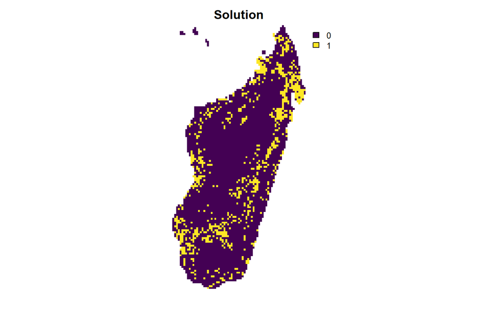

```r
plot(s1, main = "Solution", axes = FALSE)
```

## How many planning units were protected in this solution?

```r
eval_n_summary(p1, s1)
```

```
## # A tibble: 1 × 2
##   summary     n
##   <chr>   <dbl>
## 1 overall   880
```

## How much does it cost?

```r
eval_cost_summary(p1, s1)
```

```
## # A tibble: 1 × 2
##   summary  cost
##   <chr>   <dbl>
## 1 overall 6308.
```

## Was each species protected 30%?

```r
p1_target_coverage <- eval_target_coverage_summary(p1, s1)
print(p1_target_coverage)
```

```
## # A tibble: 41 × 9
##    feature   met   total_amount absolute_target absolute_held absolute_shortfall
##    <chr>     <lgl>        <dbl>           <dbl>         <dbl>              <dbl>
##  1 Adansoni… TRUE           168            50.4            51                  0
##  2 Adansoni… TRUE           503           151.            151                  0
##  3 Aerangis… TRUE           385           116.            168                  0
##  4 Andropog… TRUE           324            97.2            98                  0
##  5 Bismarck… TRUE           259            77.7            78                  0
##  6 Buddleja… TRUE           362           109.            109                  0
##  7 Bulbophy… TRUE           123            36.9            69                  0
##  8 Combretu… TRUE           105            31.5            43                  0
##  9 Cordyla … TRUE           477           143.            152                  0
## 10 Croton s… TRUE           146            43.8            65                  0
## # ℹ 31 more rows
## # ℹ 3 more variables: relative_target <dbl>, relative_held <dbl>,
## #   relative_shortfall <dbl>
```

## What percentage of species had at least 30% of their range protected?

```r
print(mean(p1_target_coverage$met) * 100)
```

```
## [1] 100
```

# Exercise 2

What would be the solution if we require a minimum of 70% of the species range to be protected?

Hint: replace the value in `add_relative_targets()`

```
# calculate budget
budget <- terra::global(cost, "sum", na.rm = TRUE)[[1]] * 0.3

# create problem
pt <-
  problem(cost, features = species) %>%
  add_min_shortfall_objective(budget) %>%
  add_relative_targets(0.3) %>% # change this line
  add_binary_decisions() %>%
  add_default_solver(gap = 0.1, verbose = FALSE)

# print problem
print(pt)

st <- solve(pt)

pt_target_coverage <- eval_target_coverage_summary(pt, st)
print(pt_target_coverage)


print(mean(pt_target_coverage$met) * 100)
```

Note that a lot of species still have 70% of their range protected… How might this be possible when we are only protecting what we can purchase with 30% of our budget (which is close to 30% of the area of Madagascar)? This is because many species will have a range that is smaller than ~30% of Madagascar, so protecting ~30% will protect >30% of many species ranges, especially if they are narrow range species.

# Adding existing PAs

Madagascar already had a Protected Area network. Do the areas we are protecting overlap with the existing protected areas? Perhaps we should develop protected areas that complement and enhance the existing ones.

## Load in PA data

We can load in the PA data, but note that it also needs to be re-scaled so that the code will run faster.

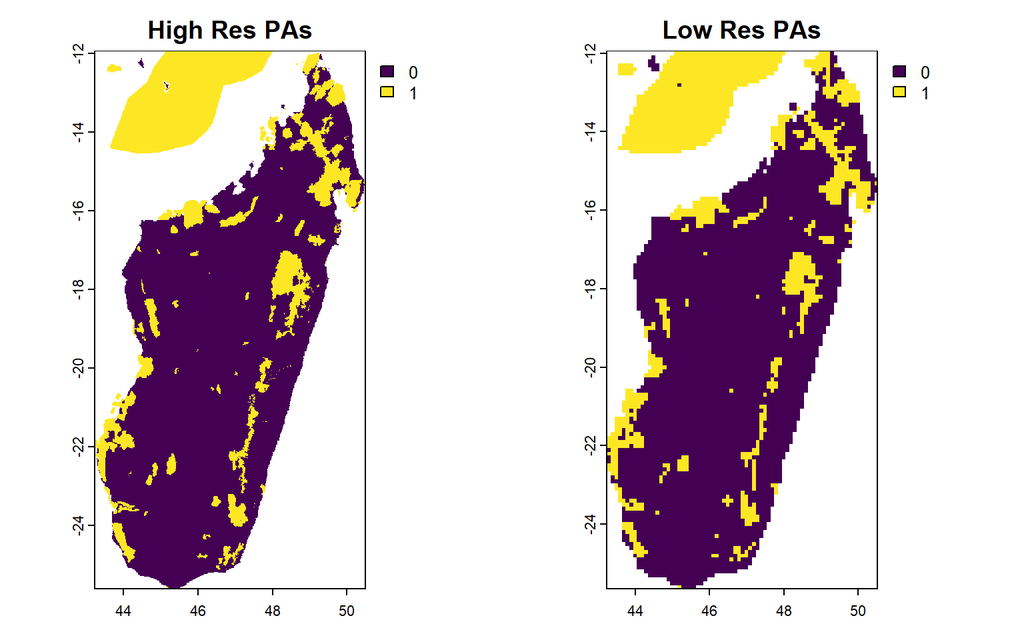

```r
# load protected areas
PAs = terra::rast("data/locked_in.tif")

#add the land in
PAs = ifel((!is.na(cost0) & is.na(PAs)),0,PAs )

# Re-scale
par(mfrow = c(1,2))
plot(PAs, main="High Res PAs")
PAs = terra::aggregate(PAs, fact = 12, fun = "modal",  na.rm=TRUE)
plot(PAs, main="Low Res PAs")
```

```r
par(mfrow = c(1,1))
```

Notice that some PAs get swallowed up by the resolution change.

## Modify the problem to add PAs

The function `add_locked_in_constraints()` allows us to add in areas that are “locked in” i.e. already conserved or protected.

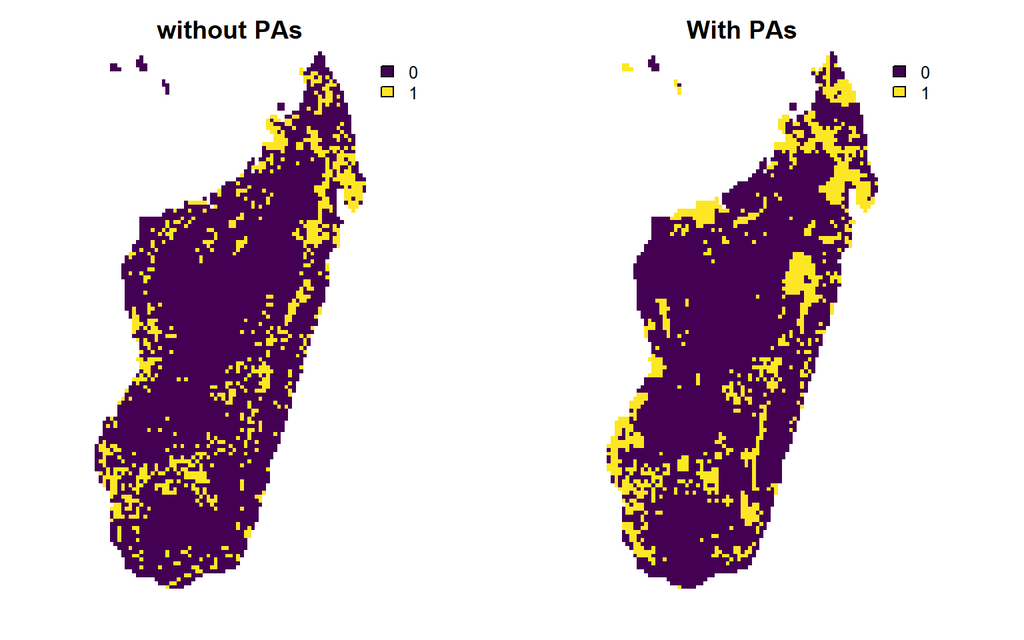

```r
# create new problem where protected areas are locked in
p2 <-  p1 %>%
  add_locked_in_constraints(PAs) # this is the only new line

# solve the problem
s2 <- solve(p2)

# plot the solution
par(mfrow=c(1,2)) # split plot into 2 panels
plot(s1, main = "without PAs", axes = FALSE)
plot(s2, main = "With PAs", axes = FALSE)
```

```r
par(mfrow=c(1,1)) # Go back to one plot


# calculate the number of selected planning units in the solution
eval_n_summary(p2, s2)
```

```
## # A tibble: 1 × 2
##   summary     n
##   <chr>   <dbl>
## 1 overall  1080
```

```r
# calculate the total cost of the solution
eval_cost_summary(p2, s2)
```

```
## # A tibble: 1 × 2
##   summary  cost
##   <chr>   <dbl>
## 1 overall 7961.
```

```r
# Note that the scenario is more expensive - why do you think that is?
# It is likely the first scenario has no constraints and protects the cheapest sites first
# that meet the biodiversity target. However, some of these sites are already protected in scenario 2,
# so the algorithm has to consider sites that are not already protected, which are more expensive
# in order to meet the conservation scenario.
# The more we protect, the more expensive it gets because we use the cheaper sites at the
# beginning, and add more and more costly sites as we go on


# calculate target coverage for the solution
p2_target_coverage <- eval_target_coverage_summary(p2, s2)
print(p2_target_coverage)
```

```
## # A tibble: 41 × 9
##    feature   met   total_amount absolute_target absolute_held absolute_shortfall
##    <chr>     <lgl>        <dbl>           <dbl>         <dbl>              <dbl>
##  1 Adansoni… TRUE           168            50.4            51                  0
##  2 Adansoni… TRUE           503           151.            152                  0
##  3 Aerangis… TRUE           385           116.            187                  0
##  4 Andropog… TRUE           324            97.2            98                  0
##  5 Bismarck… TRUE           259            77.7            78                  0
##  6 Buddleja… TRUE           362           109.            115                  0
##  7 Bulbophy… TRUE           123            36.9            77                  0
##  8 Combretu… TRUE           105            31.5            67                  0
##  9 Cordyla … TRUE           477           143.            196                  0
## 10 Croton s… TRUE           146            43.8            78                  0
## # ℹ 31 more rows
## # ℹ 3 more variables: relative_target <dbl>, relative_held <dbl>,
## #   relative_shortfall <dbl>
```

```r
# check percentage of the features that have their target met given the solution
print(mean(p2_target_coverage$met) * 100)
```

```
## [1] 100
```

# Add boundary penalty

We can further modify the problem by adding penalties that punish overly fragmented solutions (via `add_boundary_penalties()`). Here we will use a penalty factor (i.e., boundary length modifier) of 0.003, and an edge factor of 50% so that planning units that occur on the outer edge of the study area are not overly penalized.

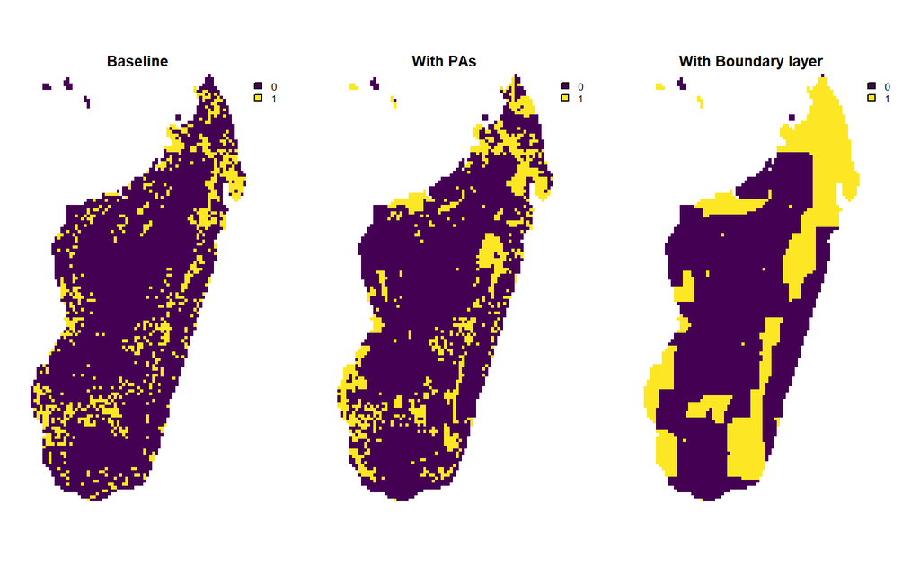

```r
# create a new problem with boundary penalties added to it
p3 <-
  p2 %>%
  add_boundary_penalties(penalty = 0.003, edge_factor = 0.5)

# solve the problem
s3 <- solve(p3)

# plot the solution
par(mfrow=c(1,3))# split into 3 plots side by side
plot(s1, main = "Baseline", axes = FALSE)
plot(s2, main = "With PAs", axes = FALSE)
plot(s3, main = "With Boundary layer", axes = FALSE)
```

```r
par(mfrow=c(1,1))# go back to only 1 plot

# calculate target coverage for the solution
p3_target_coverage <- eval_target_coverage_summary(p3, s3)
print(p3_target_coverage)
```

```
## # A tibble: 41 × 9
##    feature   met   total_amount absolute_target absolute_held absolute_shortfall
##    <chr>     <lgl>        <dbl>           <dbl>         <dbl>              <dbl>
##  1 Adansoni… TRUE           168            50.4            75                  0
##  2 Adansoni… TRUE           503           151.            153                  0
##  3 Aerangis… TRUE           385           116.            291                  0
##  4 Andropog… TRUE           324            97.2           106                  0
##  5 Bismarck… TRUE           259            77.7            78                  0
##  6 Buddleja… TRUE           362           109.            156                  0
##  7 Bulbophy… TRUE           123            36.9           102                  0
##  8 Combretu… TRUE           105            31.5            80                  0
##  9 Cordyla … TRUE           477           143.            247                  0
## 10 Croton s… TRUE           146            43.8           124                  0
## # ℹ 31 more rows
## # ℹ 3 more variables: relative_target <dbl>, relative_held <dbl>,
## #   relative_shortfall <dbl>
```

```r
# check the percentage of the features that have their target met given the solution
print(mean(p3_target_coverage$met) * 100)
```

```
## [1] 100
```

What is the first thing you notice? It’s much longer… This is because it has to compute a lot more relationships between cells/planning units.

# Calculate importance scores

Irreplaceability tells you how important each cell is to the solution: if it is red, you absolutely need to protect that cell. If it is beige, it is interchangeable with other cells. If you have a lot of common species (like we do), then most of them will be beige, but if you have rare narrow range endemics, then those cells will become red (because they only occur in a few locations where they must be protected otherwise they will be lost).

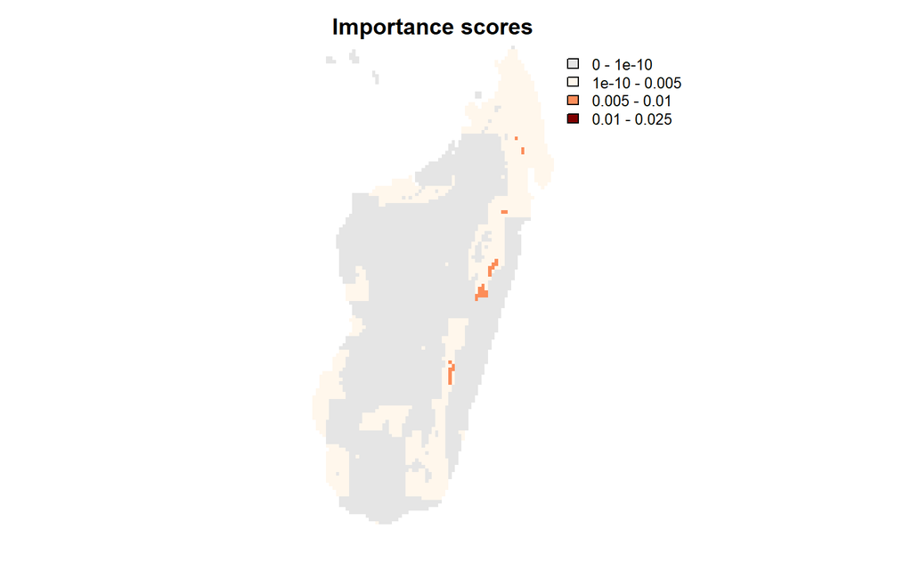

```r
rc <-
  p3 %>%
  eval_ferrier_importance(s3)

# plot the total importance scores
## note that gray cells are not selected by the prioritization
plot(
  rc[["total"]], main = "Importance scores", axes = FALSE,
  breaks = c(0, 1e-10, 0.005, 0.01, 0.025),
  col = c("#e5e5e5", "#fff7ec", "#fc8d59", "#7f0000")
)
```

# Exercise 3: Lock out land from conservation

As an exercise, you will “lock out” some areas from protection. These are places like cities that should be ignored from the prioritisation.

Go find the `locked_out.tif` raster in your data directory and use `terra::rast` to import it. Then use the `add_locked_out_constraints()` to lock out your raster from the p2 problem we formulated. If you want you can also plot the locked_out data layer

```
locked_out = terra::rast("data/locked_out.tif")

# create new problem with boundary penalties added to it
p4 <-
  p2 %>%
  # add your locked out constraint here: add_locked_out_constraints(locked_out)

# solve the problem
s4 <- solve(p4)

# plot the solution
par(mfrow=c(2,2))# split into 4 plots side by side
plot(s1, main = "Baseline", axes = FALSE)
plot(s2, main = "With PAs", axes = FALSE)
plot(s4, main = "With PAs + Avoid cities", axes = FALSE)
plot(s3, main = "With PAs + Boundary layer", axes = FALSE)
par(mfrow=c(1,1))# go back to only 1 plot
```

Notice that it reality it doesn’t change much because we are using the same data to derive the cost layer and the locked out layer. However locking areas out of the prioritisation means that some “expensive” but biodiverse sites cannot be protected, and need to be replaced with more and cheaper planning units, meaning that more land has to be protected in compensation…

```
# calculate target coverage for the solution
p4_target_coverage <- eval_target_coverage_summary(p4, s4)
print(p4_target_coverage)

# check the percentage of the features that have their target met given the solution
print(mean(p4_target_coverage$met) * 100)
```

# Exercise 4: Implementing Marxan

Marxan addresses conservation problems the opposite way round to prioritizr. It tries to find the cheapest solution (that will impact the least people) while meeting the biodiversity target (here to protect 30% of the range of each species). This can be done by replacing `add_min_shortfall_objective(budget)` with `add_min_set_objective()` in the `p1` solution. We no longer rely on a budget.

```
py <-
  problem(cost, features = species) %>%
  add_min_shortfall_objective(budget) %>% # replace this with add_min_set_objective()
  add_relative_targets(0.3) %>%
  add_binary_decisions() %>%
  add_locked_in_constraints(PAs) %>%
  add_default_solver(gap = 0.1, verbose = FALSE)

sy <- solve(py)

# changed the plot colours because why not
# plot the solution
par(mfrow=c(1,2))# split into 2 plots side by side
plot(s2, main = "maximise biodiversity", axes = FALSE)
plot(sy, main = "minimise cost", axes = FALSE)
par(mfrow=c(1,1))# go back to only 1 plot
```

# Exercise 5: Ignore cost

So far we have used cost as the human footprint layer, but what if we want to just ignore cost and look only at the biodiversity? We are going to create a new cost layer called `cost_null` where cost is set to 1 on land, and NA everywhere else. We will then replace `cost` with `cost_null` in`problem(cost, features = species)`. How does it compare to the layer with cost?

Hint: replace all `cost` with `cost_null` in `budget` and `pr`

```
cost_null = ifel(!is.na(cost),1,NA)

# calculate budget
budget <- terra::global(cost, "sum", na.rm = TRUE)[[1]] * 0.3 # replace cost with cost_null here

# create problem
pr <-
  problem(cost, features = species) %>% # replacee cost with cost_null here
  add_min_shortfall_objective(budget) %>%
  add_relative_targets(0.3) %>%
  add_binary_decisions() %>%
  add_default_solver(gap = 0.1, verbose = FALSE)


sr <- solve(pr)

# plot the solution
par(mfrow=c(1,2))# split into 2 plots side by side
plot(s1, main = "with cost", axes = FALSE)
plot(sr, main = "without cost", axes = FALSE)
par(mfrow=c(1,1))# go back to only 1 plot
```